# L-Infinity CSTs: From Normalization to Disease Associations

The `linf` package implements L-infinity normalization and Dominant Community State Types (DCSTs) for compositional data. This vignette demonstrates the complete workflow in two parts: first a quick-start with toy data to introduce the core functions, then a real-data analysis of gut microbiome samples from the American Gut Project showing that DCSTs capture clinically meaningful dominance patterns.

## Part 1: Quick Start with Toy Data

### L-infinity normalization

L-infinity normalization scales each row of a count matrix by its maximum value, projecting samples onto the L-infinity unit ball. Every normalized row has a maximum of exactly 1.

```r
set.seed(1)
S.counts <- matrix(
  rpois(30, lambda = 5),
  nrow = 10, ncol = 3,
  dimnames = list(paste0("s", 1:10), c("Taxon_A", "Taxon_B", "Taxon_C"))
)

Z <- normalize.linf(S.counts)
apply(Z, 1, max)   # all 1
```

```
#>  s1  s2  s3  s4  s5  s6  s7  s8  s9 s10
#>   1   1   1   1   1   1   1   1   1   1
```

### L-infinity cells

Each sample is assigned to the column achieving its maximum—its *L-infinity cell*. This is the dominant feature.

```r
cells <- linf.cells(Z)
table(cells$label)
```

```
#>
#> Taxon_A Taxon_B Taxon_C
#>       4       4       2
```

### Truncated CSTs

`linf.csts()` groups samples by dominant feature and collapses small groups (below threshold `n0`) into a `RARE_DOMINANT` bucket. This produces *Dominant Community State Types* (DCSTs).

```r
A <- matrix(c(5, 1, 0), nrow = 6, ncol = 3, byrow = TRUE)
B <- matrix(c(1, 5, 0), nrow = 2, ncol = 3, byrow = TRUE)
C <- matrix(c(1, 0, 5), nrow = 2, ncol = 3, byrow = TRUE)
S <- rbind(A, B, C)
S <- sweep(S, 1, rowSums(S), "/")
colnames(S) <- c("Dom1", "Dom2", "Dom3")

res <- linf.csts(S, n0 = 5)
table(res$cell.label, useNA = "ifany")
```

```
#>
#>          Dom1 RARE_DOMINANT
#>             6             4
```

Only Dom1 (6 samples) meets the `n0 = 5` threshold. Dom2 and Dom3 are collapsed into `RARE_DOMINANT`.

## Part 2: Gut Microbiome DCSTs and Disease

### Background

In the vaginal microbiome, single-species dominance is common and generally healthy—for instance, *Lactobacillus crispatus* dominance defines CST I, the healthiest community state. The gut is fundamentally different. Healthy gut communities are diverse, and single-species dominance is rare and often associated with pathology: post-antibiotic *Enterococcus* blooms, *Clostridioides* overgrowth in IBD, and similar dysbiotic states.

This means that DCSTs applied to gut data should produce a large “mixed” majority (many taxa share abundance) alongside a tail of strongly dominated samples—and those dominated samples may be enriched for disease. This is a powerful use case for DCSTs: they identify clinically meaningful dominance patterns *without any clustering*.

### The data

The `agp_gut` dataset bundled with this package contains 766 gut microbiome samples from the American Gut Project (PRJEB11419), a citizen-science 16S rRNA V4 survey. The dataset is a stratified subsample designed to preserve rare disease-associated community types while keeping the file size small enough for CRAN.

```r
data(agp_gut)
str(agp_gut, max.level = 1)
```

```
#> List of 4
#>  $ counts: int [1:766, 1:314] 464 5 0 0 23 0 0 0 3 0 ...
#>   ..- attr(*, "dimnames")=List of 2
#>  $ meta  :'data.frame':  766 obs. of  15 variables:
#>  $ taxa  : chr [1:314] "d__Archaea;p__Euryarchaeota;c__Methanobacteria;o__Methanobacteriales;f__Methanobacteriaceae;g__Methanobrevibacter;s__" "d__Bacteria;__;__;__;__;__;__" "d__Bacteria;p__Actinobacteriota;c__Actinobacteria;o__Actinomycetales;f__Actinomycetaceae;g__Actinomyces;s__" "d__Bacteria…
#>  $ source: chr "Stratified subsample (n=766) from the American Gut Project (PRJEB11419, AGP-US-2015). Original dataset: ~26,900"| __truncated__
```

```r
dim(agp_gut$counts)   # samples x taxa
```

```
#> [1] 766 314
```

Metadata includes self-reported health conditions parsed from the AGP questionnaire:

```r
disease_cols <- c("IBS", "IBD", "Obesity", "Cardiovascular_disease",
                  "Autoimmune", "Acid_reflux")
sapply(disease_cols, function(col) sum(agp_gut$meta[[col]], na.rm = TRUE))
```

```
#>                    IBS                    IBD                Obesity
#>                    103                     38                    158
#> Cardiovascular_disease             Autoimmune            Acid_reflux
#>                     47                     88                     72
```

### Step 1: Quality filtering

`filter.asv()` removes low-depth samples and rare taxa in one call. We require at least 1,000 reads per sample and taxa present in at least 5% of samples.

```r
filt <- filter.asv(agp_gut$counts, min.lib = 1000, prev.prop = 0.05,
                   min.count = 2)
```

```
#> Samples kept: 764 / 766  (min.lib = 1000)
#> Features kept: 314 / 314  (prev.prop = 0.05, prev.thld = 39)
```

```r
dim(filt$counts)
```

```
#> [1] 764 314
```

```r
dim(filt$rel)
```

```
#> [1] 764 314
```

### Step 2: L-infinity normalization

```r
M <- normalize.linf(filt$counts)

# Verify: every row max is 1
stopifnot(all(abs(apply(M, 1, max) - 1) < 1e-10))
```

### Step 3: Depth-1 DCSTs

```r
csts <- linf.csts(M, n0 = 30)

# DCST size distribution
sort(table(csts$cell.label), decreasing = TRUE)
```

```
#>
#>                                                                                                              RARE_DOMINANT
#>                                                                                                                        224
#>                           d__Bacteria;p__Bacteroidota;c__Bacteroidia;o__Bacteroidales;f__Bacteroidaceae;g__Bacteroides;s__
#>                                                                                                                        154
#> d__Bacteria;p__Proteobacteria;c__Gammaproteobacteria;o__Enterobacterales;f__Enterobacteriaceae;g__Escherichia-Shigella;s__
#>                                                                                                                        106
#>                          d__Bacteria;p__Bacteroidota;c__Bacteroidia;o__Bacteroidales;f__Prevotellaceae;g__Prevotella_7;s__
#>                                                                                                                         89
#>                        d__Bacteria;p__Firmicutes;c__Bacilli;o__Staphylococcales;f__Staphylococcaceae;g__Staphylococcus;s__
#>                                                                                                                         77
#>           d__Bacteria;p__Verrucomicrobiota;c__Verrucomicrobiae;o__Verrucomicrobiales;f__Akkermansiaceae;g__Akkermansia;s__
#>                                                                                                                         63
#>                          d__Bacteria;p__Proteobacteria;c__Gammaproteobacteria;o__Enterobacterales;f__Pasteurellaceae;__;__
#>                                                                                                                         51
```

Note on *Escherichia-Shigella*: this genus is known to be inflated in 16S V4 data due to primer cross-reactivity. Its high prevalence should be interpreted with caution.

### Step 4: Depth-2 refinement

`refine.linf.csts()` subdivides large DCSTs by their *subdominant* species. For instance, a Bacteroides-dominated sample might be further classified by whether its second-most-abundant taxon is *Faecalibacterium* or *Lachnospiraceae*. This captures co-dominance patterns that are especially important in the diverse gut environment.

```r
csts2 <- refine.linf.csts(M, csts, n0 = 30)
```

```
#> ========================================
#> AUTO-REFINEMENT MODE
#> ========================================
#> Refinement threshold: 60
#> Cells selected for refinement: 6
```

```r
# Show depth-2 DCSTs with >= 20 samples
tab2 <- sort(table(csts2$cell.label), decreasing = TRUE)
tab2[tab2 >= 20]
```

```
#>
#>                                                                                                              RARE_DOMINANT
#>                                                                                                                        224
#>                           d__Bacteria;p__Bacteroidota;c__Bacteroidia;o__Bacteroidales;f__Bacteroidaceae;g__Bacteroides;s__
#>                                                                                                                        154
#> d__Bacteria;p__Proteobacteria;c__Gammaproteobacteria;o__Enterobacterales;f__Enterobacteriaceae;g__Escherichia-Shigella;s__
#>                                                                                                                        106
#>                          d__Bacteria;p__Bacteroidota;c__Bacteroidia;o__Bacteroidales;f__Prevotellaceae;g__Prevotella_7;s__
#>                                                                                                                         89
#>                        d__Bacteria;p__Firmicutes;c__Bacilli;o__Staphylococcales;f__Staphylococcaceae;g__Staphylococcus;s__
#>                                                                                                                         77
#>           d__Bacteria;p__Verrucomicrobiota;c__Verrucomicrobiae;o__Verrucomicrobiales;f__Akkermansiaceae;g__Akkermansia;s__
#>                                                                                                                         63
#>                          d__Bacteria;p__Proteobacteria;c__Gammaproteobacteria;o__Enterobacterales;f__Pasteurellaceae;__;__
#>                                                                                                                         51
```

### Dominance strength

A useful diagnostic: the relative abundance of the dominant species in each sample. In the gut, most samples have modest dominance (< 50%), consistent with the diverse nature of the ecosystem.

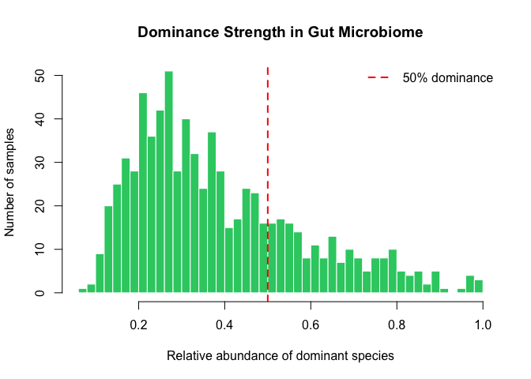

Distribution of dominance strength across gut samples. Most samples show moderate dominance, with a tail of strongly dominated communities.

```r
rel <- filt$rel
dom_strength <- apply(rel, 1, max)
hist(dom_strength, breaks = 50, col = "#2ecc71", border = "white",
     main = "Dominance Strength in Gut Microbiome",
     xlab = "Relative abundance of dominant species",
     ylab = "Number of samples")
abline(v = 0.5, col = "red", lty = 2, lwd = 2)
legend("topright", "50% dominance", col = "red", lty = 2, lwd = 2, bty = "n")
```

### DCST size distribution

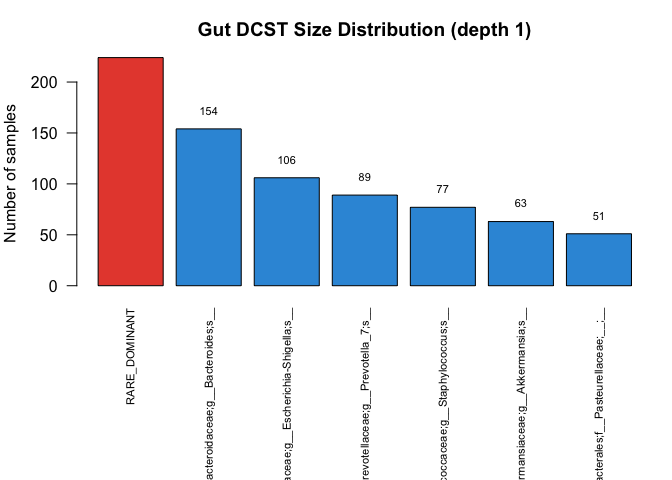

DCST size distribution at depth 1. Bacteroides and Escherichia-Shigella dominate; rare DCSTs in the tail are collapsed into RARE_DOMINANT.

```r
tab1 <- sort(table(csts$cell.label), decreasing = TRUE)
par(mar = c(10, 4, 3, 1))
bp <- barplot(tab1,
        col = ifelse(names(tab1) == "RARE_DOMINANT", "#e74c3c", "#3498db"),
        las = 2, cex.names = 0.7,
        ylab = "Number of samples",
        main = "Gut DCST Size Distribution (depth 1)")
text(bp, tab1 + 5, labels = tab1, cex = 0.7, pos = 3)
```

### Disease associations

The central question: do samples with unusual dominant species show different disease profiles? For each DCST with sufficient samples, we test whether the prevalence of self-reported health conditions differs from the population rate using Fisher’s exact test.

```r
# Align metadata to filtered samples
meta <- agp_gut$meta[match(rownames(M), agp_gut$meta$Run), ]
stopifnot(all(meta$Run == rownames(M)))

# Helper: shorten SILVA taxonomy to genus (or last named rank)
shorten_taxon <- function(x) {
  sapply(x, function(s) {
    if (s == "RARE_DOMINANT") return(s)
    ranks <- strsplit(s, ";")[[1]]
    # Try genus first, then walk up
    for (prefix in c("g__", "f__", "o__", "c__")) {
      hit <- grep(prefix, ranks, value = TRUE)
      if (length(hit) > 0) {
        name <- sub(paste0(".*", prefix), "", hit[length(hit)])
        if (nzchar(name)) return(name)
      }
    }
    s  # fallback: return as-is
  }, USE.NAMES = FALSE)
}

# Conditions to test
conditions <- c("IBS", "IBD", "Obesity", "Cardiovascular_disease",
                "Autoimmune", "Acid_reflux", "Lung_disease")

dcst_labels <- csts$cell.label
kept_dcsts  <- names(tab1[tab1 >= 20])

results <- data.frame()

for (dcst in kept_dcsts) {
  in_dcst <- dcst_labels == dcst

  for (cond in conditions) {
    d <- meta[[cond]]
    if (is.null(d) || all(is.na(d))) next

    a <- sum(in_dcst & d == 1, na.rm = TRUE)
    b <- sum(in_dcst & d == 0, na.rm = TRUE)
    cc <- sum(!in_dcst & d == 1, na.rm = TRUE)
    dd <- sum(!in_dcst & d == 0, na.rm = TRUE)

    ft <- fisher.test(matrix(c(a, b, cc, dd), nrow = 2))

    results <- rbind(results, data.frame(
      DCST      = dcst,
      Condition = cond,
      n_DCST    = sum(in_dcst),
      n_cases   = a,
      prev_DCST = round(a / sum(in_dcst), 3),
      prev_pop  = round((a + cc) / length(dcst_labels), 3),
      OR        = round(ft$estimate, 2),
      p_value   = ft$p.value,
      stringsAsFactors = FALSE
    ))
  }
}

# Multiple testing correction (Benjamini-Hochberg)
results$q_value <- p.adjust(results$p_value, method = "BH")
results <- results[order(results$p_value), ]
rownames(results) <- NULL
```

```r
# Shorten DCST names for display
results$DCST <- shorten_taxon(results$DCST)

# Significant associations (q < 0.1)
sig <- results[results$q_value < 0.1, ]
if (nrow(sig) > 0) {
  sig$p_value <- formatC(sig$p_value, format = "e", digits = 2)
  sig$q_value <- formatC(sig$q_value, format = "e", digits = 2)
  knitr::kable(sig, caption = "DCST-disease associations (q < 0.1)",
               row.names = FALSE)
} else {
  cat("No associations reached q < 0.1 in this subset.\n")
  cat("Showing top 10 by p-value:\n")
  top10 <- head(results, 10)
  top10$p_value <- formatC(top10$p_value, format = "e", digits = 2)
  top10$q_value <- formatC(top10$q_value, format = "e", digits = 2)
  knitr::kable(top10, caption = "Top 10 DCST-disease associations by p-value",
               row.names = FALSE)
}
```

DCST-disease associations (q < 0.1)

| DCST | Condition | n_DCST | n_cases | prev_DCST | prev_pop | OR | p_value | q_value |
| --- | --- | --- | --- | --- | --- | --- | --- | --- |
| Bacteroides | Obesity | 154 | 57 | 0.370 | 0.207 | 2.96 | 1.06e-07 | 5.19e-06 |
| Escherichia-Shigella | IBS | 106 | 28 | 0.264 | 0.135 | 2.79 | 9.84e-05 | 2.41e-03 |
| Staphylococcus | Obesity | 77 | 5 | 0.065 | 0.207 | 0.24 | 5.52e-04 | 5.58e-03 |
| Pasteurellaceae | Cardiovascular_disease | 51 | 10 | 0.196 | 0.062 | 4.44 | 5.62e-04 | 5.58e-03 |
| RARE_DOMINANT | Obesity | 224 | 29 | 0.129 | 0.207 | 0.47 | 5.70e-04 | 5.58e-03 |
| Prevotella_7 | Cardiovascular_disease | 89 | 0 | 0.000 | 0.062 | 0.00 | 3.96e-03 | 3.23e-02 |
| Prevotella_7 | Obesity | 89 | 29 | 0.326 | 0.207 | 2.04 | 5.05e-03 | 3.54e-02 |
| Escherichia-Shigella | Acid_reflux | 106 | 18 | 0.170 | 0.094 | 2.28 | 6.87e-03 | 3.95e-02 |
| Prevotella_7 | Lung_disease | 89 | 2 | 0.022 | 0.099 | 0.19 | 7.26e-03 | 3.95e-02 |
| Pasteurellaceae | IBS | 51 | 1 | 0.020 | 0.135 | 0.12 | 9.23e-03 | 4.52e-02 |
| Prevotella_7 | Acid_reflux | 89 | 2 | 0.022 | 0.094 | 0.20 | 1.08e-02 | 4.82e-02 |
| Prevotella_7 | IBD | 89 | 0 | 0.000 | 0.050 | 0.00 | 1.62e-02 | 6.61e-02 |
| Staphylococcus | Cardiovascular_disease | 77 | 10 | 0.130 | 0.062 | 2.62 | 1.98e-02 | 6.97e-02 |
| Prevotella_7 | IBS | 89 | 5 | 0.056 | 0.135 | 0.35 | 1.99e-02 | 6.97e-02 |
| Staphylococcus | IBS | 77 | 4 | 0.052 | 0.135 | 0.33 | 2.18e-02 | 7.11e-02 |
| Staphylococcus | IBD | 77 | 0 | 0.000 | 0.050 | 0.00 | 2.55e-02 | 7.82e-02 |
| Escherichia-Shigella | Lung_disease | 106 | 17 | 0.160 | 0.099 | 1.94 | 3.42e-02 | 9.52e-02 |
| Staphylococcus | Autoimmune | 77 | 3 | 0.039 | 0.114 | 0.29 | 3.50e-02 | 9.52e-02 |

### Interpreting the results

Several patterns emerge that are consistent with known gut microbiome biology:

**Prevotella_7 and obesity.** *Prevotella* species are associated with carbohydrate-rich diets and higher BMI in multiple cohort studies. The DCST framework identifies this without any prior clustering or reference database—purely from the compositional geometry. (Note: this association could be confounded by diet; see Limitations.)

**Oral taxa and cardiovascular disease.** Pasteurellaceae and Staphylococcus are primarily oral or skin-associated taxa. Their appearance as dominant gut taxa likely reflects sample contamination, but their disease associations are biologically plausible: oral health and cardiovascular disease are epidemiologically linked, and the same individuals with poor oral hygiene may produce contaminated stool samples.

**Escherichia-Shigella and IBS.** Enterobacteriaceae enrichment is a widely reported feature of IBS and IBD. The DCST framework captures this as a natural dominance pattern.

**RARE_DOMINANT.** Samples in the rare-dominant bucket are dominated by unusual taxa that don’t form their own DCST. In the full 5,000-sample analysis, this group shows distinct disease profiles, consistent with the idea that unusual gut dominance is a marker of dysbiosis.

These associations are based on univariate Fisher’s exact tests and do not account for potential confounders such as age, sex, diet, BMI, or geography. A full analysis with covariate-adjusted logistic regression and validation in an independent cohort is in preparation.

## Limitations

This analysis has several important caveats:

- **Self-reported metadata.** AGP health conditions are self-reported by citizen-science participants, with unknown accuracy.
- **No covariate adjustment.** The Fisher’s exact tests are univariate. Age, sex, diet, and geography could confound these associations. A full analysis should use logistic regression with covariates.
- **16S resolution.** The Escherichia-Shigella inflated abundance is a known V4 artifact. Shotgun metagenomics would resolve this.
- **Stratified subsample.** This dataset was intentionally enriched for rare DCSTs and disease cases to demonstrate the method. The effect sizes shown here are not directly comparable to population-level estimates from the full AGP cohort.

For the complete 5,000-sample analysis without stratification bias, see the companion pkgdown article `vignette("gut-dcst-disease-analysis", package = "linf")`.

## Summary

The L-infinity DCST framework provides a clustering-free approach to community typing that is deterministic, hierarchical, and biologically interpretable. In the gut microbiome, where single-species dominance is atypical and often pathological, DCSTs naturally identify the clinically meaningful tail of the dominance distribution. The combination of depth-1 DCSTs (dominant species) and depth-2 refinement (co-dominance patterns) captures structure at multiple resolutions without requiring any parameter tuning beyond the minimum cell-size threshold `n0`.